# Exercise Quality prediction

Report by Carlos Neves

for [Practical Machine learning](https://www.coursera.org/learn/practical-machine-learning) course.

## Introduction

Using devices such as Jawbone Up, Nike FuelBand, and Fitbit it is now possible to collect a large amount of data about personal activity relatively inexpensively. These type of devices are part of the quantified self movement – a group of enthusiasts who take measurements about themselves regularly to improve their health, to find patterns in their behaviour, or because they are tech geeks. One thing that people regularly do is quantify *how much of a particular activity they do*, but they rarely quantify *how well they do it*.

## Aim

In this project, 6 participants were asked to perform barbell lifts correctly and incorrectly in 5 different ways. The data from **accelerometers** on the **belt, forearm, arm, and dumbell** will be used to predict how well the barbell lifts were performed. The data used for this analysis was previously divided as [training set](https://d396qusza40orc.cloudfront.net/predmachlearn/pml-training.csv) and the [test set](https://d396qusza40orc.cloudfront.net/predmachlearn/pml-testing.csv) to predict. These data are based on the study [Human Activity Recognition](http://groupware.les.inf.puc-rio.br/har).

## Analysis

### Initial setting

- To guarantee reproducibility, the seed 452 was set.
- The analysis requires the package caret (**C**lassification **A**nd **Re**gression **T**raining) for model building
- The data from the study was loaded and the training data was divided into train and validation datasets.

```r
# Load required package
library(caret)
library(doParallel)

# Load the raw data
train.data <- read.csv("pml-training.csv", header=TRUE)
test.data <- read.csv("pml-testing.csv", header=TRUE)

# For reproducibility
set.seed(452)

# Divide the training data for validation
train_idx <- createDataPartition(train.data$classe, p=0.7, list=FALSE)
train <- train.data[train_idx, ]
validation <- train.data[-train_idx, ]
```

### Data processing

The train data set was initially simplified by taking only the variables corresponding to the accelerometer values, since this analysis focuses in predicting the quality of the activity by using only the data from the accelerometers on the belt, forearm, arm and dumbell.

```r
# Select only the accelerometer data

accel <- grep("accel", names(train))
train <- train[, c(accel, ncol(train))]

head(train)
```

```
##    total_accel_belt var_total_accel_belt accel_belt_x accel_belt_y
## 1                 3                   NA          -21            4
## 2                 3                   NA          -22            4
## 4                 3                   NA          -22            3
## 7                 3                   NA          -22            3
## 9                 3                   NA          -20            2
## 10                3                   NA          -21            4
##    accel_belt_z total_accel_arm var_accel_arm accel_arm_x accel_arm_y
## 1            22              34            NA        -288         109
## 2            22              34            NA        -290         110
## 4            21              34            NA        -289         111
## 7            21              34            NA        -289         111
## 9            24              34            NA        -288         109
## 10           22              34            NA        -288         110
##    accel_arm_z total_accel_dumbbell var_accel_dumbbell accel_dumbbell_x
```

[output cut: 20 more lines]

As some of these variables seem to have a great number of missing values (*NA*), incomplete variables were additionally excluded.

```r
# Find incomplete variables

temp <- numeric()
for (i in 1:ncol(train)) {
    if(sum(is.na(train[,i]))!=0) {
        print(paste(i, names(train)[i], sep="   "))
        temp <- append(temp,i)
    }
}
```

```
## [1] "2   var_total_accel_belt"
## [1] "7   var_accel_arm"
## [1] "12   var_accel_dumbbell"
## [1] "17   var_accel_forearm"
```

The incomplete variables correspond to the variance of the measurements. As the mean values have more predictability value than their variance, the incomplete variables were removed.

```r
train <- train[, -temp]
names(train)
```

```
##  [1] "total_accel_belt"     "accel_belt_x"         "accel_belt_y"
##  [4] "accel_belt_z"         "total_accel_arm"      "accel_arm_x"
##  [7] "accel_arm_y"          "accel_arm_z"          "total_accel_dumbbell"
## [10] "accel_dumbbell_x"     "accel_dumbbell_y"     "accel_dumbbell_z"
## [13] "total_accel_forearm"  "accel_forearm_x"      "accel_forearm_y"
## [16] "accel_forearm_z"      "classe"
```

### Exploratory data analysis

The remaining variables were plotted to check their influence on the observed exercise quality (*classe*). Exercise quality is described as *Classe A* if it corresponds to the specified execution of the exercise, with the other 4 classes (*B* to *E*) correspond to common mistakes observed.

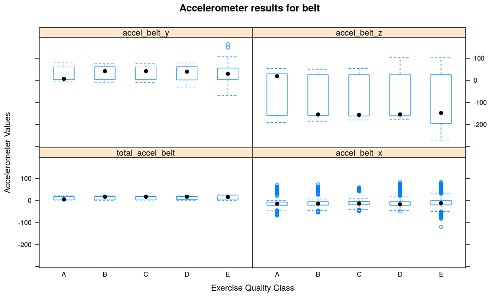

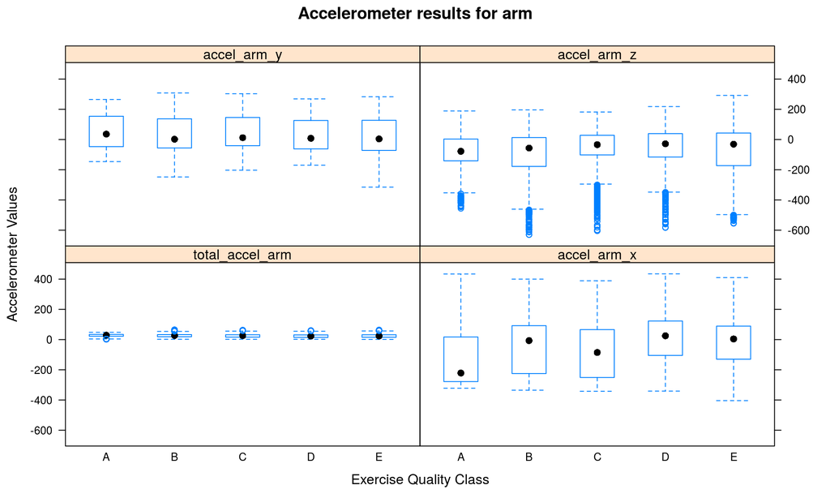

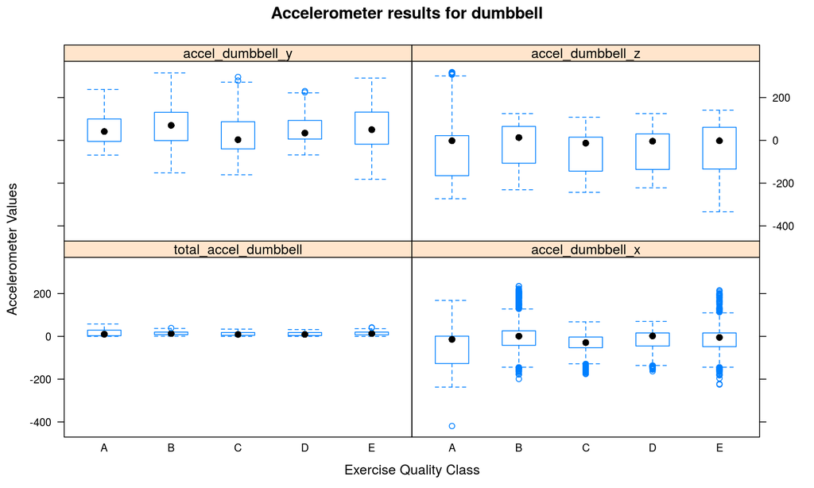

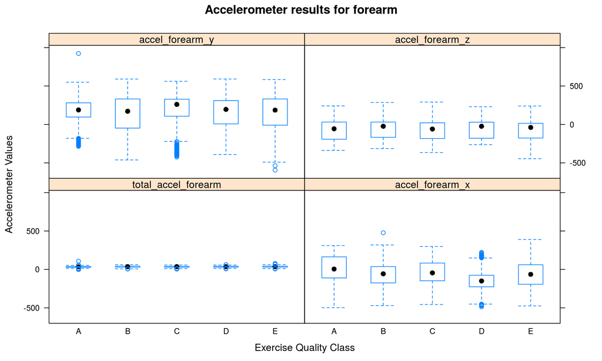

```r
# Visually explore the influence of each variable

featurePlot(x=train[,1:4], y=train$classe, plot="box", labels = c('Exercise Quality Class', 'Accelerometer Values'), main = 'Accelerometer results for belt')

featurePlot(x=train[,5:8], y=train$classe, plot="box", labels = c('Exercise Quality Class', 'Accelerometer Values'), main = 'Accelerometer results for arm')

featurePlot(x=train[,9:12], y=train$classe, plot="box", labels = c('Exercise Quality Class', 'Accelerometer Values'), main = 'Accelerometer results for dumbbell')

featurePlot(x=train[,13:16], y=train$classe, plot="box", labels = c('Exercise Quality Class', 'Accelerometer Values'), main = 'Accelerometer results for forearm')
```

All of the total measurements (*total_accel*) from the accelerometers seem to be unrelated to the *classe* of exercise and were not considered for the model.

```r
# remove "total" measurements

train <- train[, -grep('total_accel', names(train))]
names(train)
```

```
##  [1] "accel_belt_x"     "accel_belt_y"     "accel_belt_z"
##  [4] "accel_arm_x"      "accel_arm_y"      "accel_arm_z"
##  [7] "accel_dumbbell_x" "accel_dumbbell_y" "accel_dumbbell_z"
## [10] "accel_forearm_x"  "accel_forearm_y"  "accel_forearm_z"
## [13] "classe"
```

### Model building

Before bulding the model, all remaining variables were converted into numeric values.

```r
# Set all variables as numeric

for (i in 1:(ncol(train)-1)) {
    train[, i] <- as.numeric(train[, i])
}
```

Having simplified the train data and selected the most relevant variables, a random forest model (with k-fold cross-validation) was chosen to predict how well the the barbell lifts were performed. [Random forests](https://en.wikipedia.org/wiki/Random_forest) are powerful supervised algorithms that tend to be a very strong performers in a myriad of situations. The *bagging* of various Decisions tress, turn simple interpretable models into a “black box” model, lacking the transparency to fully understand how each variable affects the outcome. However, the aim of this exercise is not interpretation, but prediction and Random Forests are able to classify non-linear relationships such as those expected between the accelerometer values and the exercise quality categories.

```r
cl <- makePSOCKcluster(detectCores())
registerDoParallel(cl)

trControl <- trainControl(method = "repeatedcv", number = 10, repeats = 3, search="random")
model <- train(classe ~ ., data = train, method = "rf", prox = TRUE, tuneLength  = 15, trControl = trControl)

stopCluster(cl)

model
## Random Forest
##
## 13737 samples
##    12 predictors
##     5 classes: 'A', 'B', 'C', 'D', 'E'
##
## No pre-processing
## Resampling: Cross-Validated (10 fold, repeated 3 times)
## Summary of sample sizes: 12362, 12365, 12363, 12364, 12363, 12363, ...
## Resampling results across tuning parameters:
##
##   mtry  Accuracy   Kappa
##    1    0.9382926  0.9219148
##    2    0.9424905  0.9272388
##    3    0.9427335  0.9275477
##    4    0.9417388  0.9262958
##    5    0.9406708  0.9249397
##    6    0.9391908  0.9230729
##    7    0.9370315  0.9203415
##    8    0.9355514  0.9184659
##   10    0.9289999  0.9101724
##   12    0.9222532  0.9016279
##
## Accuracy was used to select the optimal model using the largest value.
## The final value used for the model was mtry = 3.
```

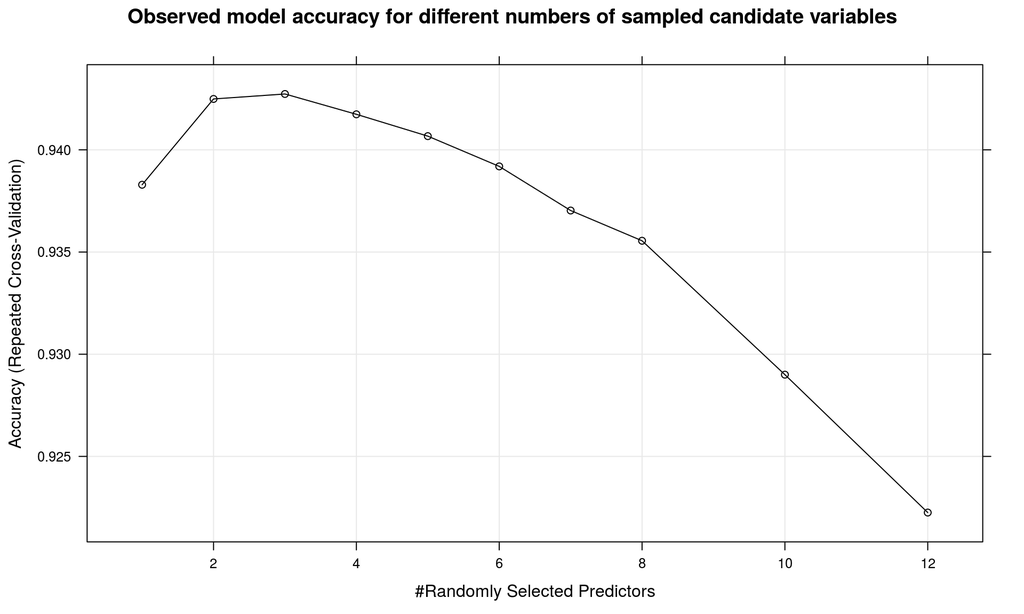

```r
trellis.par.set(caretTheme())
plot(model, main = "Observed model accuracy for different numbers of sampled candidate variables")
```

The results of the model building suggest that sampling 3 random variables (*mtry*) at each decision (split) point results in the highest model accuracy.

### Cross valiation/Out of sample error

The *in-sample-error* was measured by comparing the prediction of the model with the real value of the of the train data.

```r
# Evaluate on train data
conf_mat <- confusionMatrix(predict(model,train), train$classe)
conf_mat$table
```

```
##           Reference
## Prediction    A    B    C    D    E
##          A 3906    0    0    0    0
##          B    0 2658    0    0    0
##          C    0    0 2396    0    0
##          D    0    0    0 2252    0
##          E    0    0    0    0 2525
```

```r
conf_mat$overall
```

```
##       Accuracy          Kappa  AccuracyLower  AccuracyUpper   AccuracyNull
##      1.0000000      1.0000000      0.9997315      1.0000000      0.2843416
## AccuracyPValue  McnemarPValue
##      0.0000000            NaN
```

```r
conf_mat$byClass
```

```
##          Sensitivity Specificity Pos Pred Value Neg Pred Value Precision
## Class: A           1           1              1              1         1
## Class: B           1           1              1              1         1
## Class: C           1           1              1              1         1
## Class: D           1           1              1              1         1
## Class: E           1           1              1              1         1
##          Recall F1 Prevalence Detection Rate Detection Prevalence
## Class: A      1  1  0.2843416      0.2843416            0.2843416
## Class: B      1  1  0.1934920      0.1934920            0.1934920
## Class: C      1  1  0.1744195      0.1744195            0.1744195
## Class: D      1  1  0.1639368      0.1639368            0.1639368
## Class: E      1  1  0.1838101      0.1838101            0.1838101
##          Balanced Accuracy
## Class: A                 1
## Class: B                 1
## Class: C                 1
## Class: D                 1
## Class: E                 1
```

The fact that a high accuracy accuracy (1) is found is not strange, since the model was built from these training data. However, it could indicate over-fitting of the model to the train data. To better estimate the efficiency of the model, the model was applied to the validation data.

```r
# Evaluate on validation data
conf_mat <- confusionMatrix(predict(model,validation), validation$classe)
conf_mat$table
```

```
##           Reference
## Prediction    A    B    C    D    E
##          A 1608   39   15   17    0
##          B    9 1041   19    2   15
##          C   20   40  983   35   14
##          D   36   14    3  905   15
##          E    1    5    6    5 1038
```

```r
conf_mat$overall
```

```
##       Accuracy          Kappa  AccuracyLower  AccuracyUpper   AccuracyNull
##   9.473237e-01   9.333832e-01   9.413059e-01   9.528930e-01   2.844520e-01
## AccuracyPValue  McnemarPValue
##   0.000000e+00   8.608458e-14
```

```r
conf_mat$byClass
```

```
##          Sensitivity Specificity Pos Pred Value Neg Pred Value Precision
## Class: A   0.9605735   0.9831394      0.9577129      0.9843081 0.9577129
## Class: B   0.9139596   0.9905183      0.9585635      0.9795791 0.9585635
## Class: C   0.9580897   0.9775674      0.9001832      0.9910286 0.9001832
## Class: D   0.9387967   0.9861817      0.9301131      0.9879886 0.9301131
## Class: E   0.9593346   0.9964605      0.9838863      0.9908903 0.9838863
##             Recall        F1 Prevalence Detection Rate
## Class: A 0.9605735 0.9591411  0.2844520      0.2732370
## Class: B 0.9139596 0.9357303  0.1935429      0.1768904
## Class: C 0.9580897 0.9282342  0.1743415      0.1670348
## Class: D 0.9387967 0.9344347  0.1638063      0.1537808
## Class: E 0.9593346 0.9714553  0.1838573      0.1763806
##          Detection Prevalence Balanced Accuracy
## Class: A            0.2853016         0.9718564
## Class: B            0.1845370         0.9522390
## Class: C            0.1855565         0.9678285
## Class: D            0.1653356         0.9624892
## Class: E            0.1792693         0.9778976
```

In this case, the *out-of-sample* accuracy is 0.947, which is still very high, suggesting that the model performs well even when confronted with new data sets. Even though Random Forests are difficult to interpret, the relative importance of each variable can be extracted from the model.

```r
varImp(model)
## rf variable importance
##
##                  Overall
## accel_belt_z     100.000
## accel_dumbbell_y  85.000
## accel_dumbbell_z  74.996
## accel_arm_x       50.540
## accel_dumbbell_x  44.288
## accel_forearm_x   43.464
## accel_forearm_z   32.415
## accel_arm_y       23.405
## accel_forearm_y   18.994
## accel_arm_z       18.035
## accel_belt_x       4.709
## accel_belt_y       0.000
```

We can see that the most important variable is the z-value from the belt, which is not surprising since the studied exercises require a lifting movement. In contrast, the x- and y-values for the belt do not seem to be very important, which indicates that the belt movement is important for the lifting movement. In addition, all values for the dumbbell position are high on the importance list, suggesting that the way the dumbbell moves is critical for a correctly performed exercise.

### Prediction

```r
# Predict test data
(answers <- predict(model,test.data[,-160]))
```

```
##  [1] B A C A A E D B A A B C B A E E A B B B
## Levels: A B C D E
```

```r
# Print results in the required format
pml_write_files = function(x){
    n = length(x)
    for(i in 1:n){
        filename = paste0("problem_id_", i, ".txt")
        write.table(x[i], file = filename, quote = FALSE, row.names = FALSE, col.names = FALSE)
}
}
pml_write_files(answers)
```

#### Notes

```r
# To build html run:
library(knitr); rmarkdown::render('ExerciseQuality.Rmd')
```